# Reverse Repo & GME Correlation Analysis

u/orangecatmasterrace

2021-06-12

## Superstonk Quants Website: https://www.superstonkquant.org/

## Link to the Github repo: https://github.com/SuperstonkQuants/reddit_RRPGME_corr

```r
# Call Required Packages
library(tidyquant)
library(sqldf)
library(dplyr)
library(stringr)
library(ggpubr)
library(rmdformats)
library(roll)
```

## First, pull the GME OHLC and Reverse Repo data into R.

```r
# Pulling GME OHLC Data using the Tidyquant package
stock_data <- tq_get("GME",
                   get = "stock.prices",
                   from = "2020-01-01",
                   to = Sys.Date()
                   )

# Loading RRP Data
rrp_data <- read.csv("~/RStudio/rrp_data.csv")
# Cleaning up headers
names(rrp_data) <- str_replace_all(names(rrp_data), "[.]", "_")
```

## Subset the Reverse Repo data down to just the records that have the actual Reverse Repo Totals per day, then fix some field formats.

```r
# Subsetting RRP Data to the useful features
rrp_data_sub <- sqldf(
"
select
  Deal_Date,
  Participating_Counterparties,
  Total_Accept
from rrp_data

where Op_Type = 'RRP'
"
)

# Fixing formatting
rrp_data_sub$Deal_Date <- as.Date(rrp_data_sub$Deal_Date, "%m/%d/%Y")
rrp_data_sub$Participating_Counterparties <- as.integer(rrp_data_sub$Participating_Counterparties)
```

## Join the 2 sets of data together by date.

```r
# Joining the GME OHLC data to the RRP Data
joined_data <- sqldf(
"
select *
from rrp_data_sub r

left join stock_data s
on r.Deal_Date = s.date

where s.symbol is not null
"
)
```

## Create a scatter plot for the RRP Daily Total against GME Open.

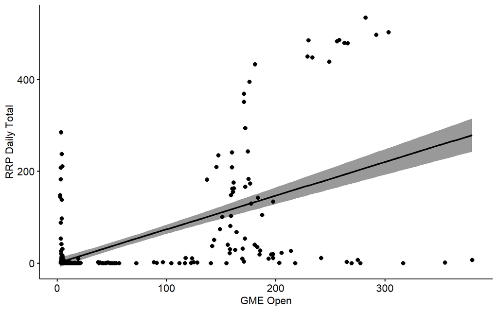

```r
# Scatter plot for RRP Total and GME Open
ggscatter(joined_data, x = "open", y = "Total_Accept",
          add = "reg.line", conf.int = TRUE,
          xlab = "GME Open", ylab = "RRP Daily Total")
```

Based on the plot, there does not appear to be a linear relationship between GME’s Open price and the RRP Daily Total. If there were a linear relationship between the values, the points would fall around the line in the middle.

## Use an ARIMA model on the GME Open values to determine if there is any reasonable lag of GME Price that can predict the Reverse Repo rate.

```r
# Choose which features to compare
x <- joined_data$open
y <- joined_data$Total_Accept

# Fit ARIMA model. Note: fit doesn't actually matter much here, just removing autoregression
ar1model = arima(x, order = c(1,1,0))

# Use residuals from ARIMA model fit on x to filter y
pwx = ar1model$residuals

newpwy = stats::filter(y,
                filter = c(1, ar1model$coef, ar1model$model$phi),
                sides = 1)
```

## Plot the Cross-Correlation between the GME Price residuals and the Reverse Repo rate.

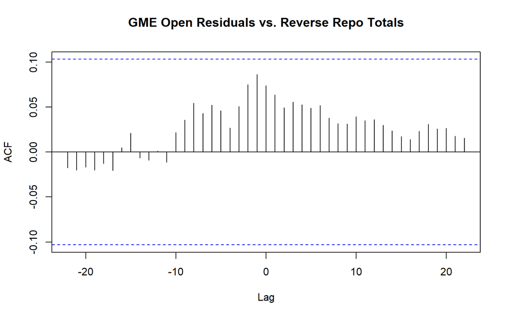

```r
# Compute cross-correlation and plot the output
ccfdata <- ccf(pwx, newpwy, na.action = na.omit, plot = FALSE)
plot(ccfdata, main = "GME Open Residuals vs. Reverse Repo Totals")
```

Since none of the vertical lines crossed the blue dotted lines, we can assume initially that these 2 variables are not correlated with each other.

## Using Differenced variables, calculate the 60-day Rolling Correlation between GME Open and RRP Totals

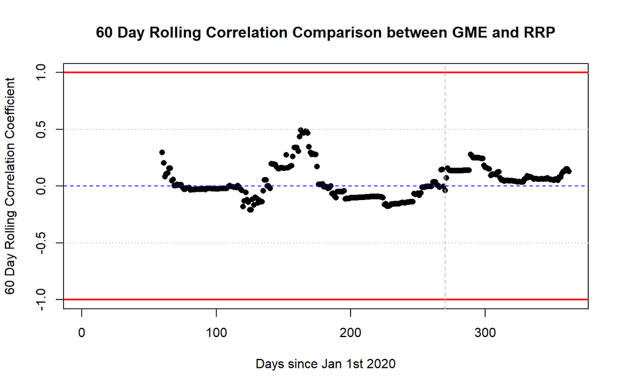

```r
# Calculate the 1-day Differences for each variable
xd = diff(joined_data$open, 1)
yd = diff(joined_data$Total_Accept, 1)

# Calculate the 60-Day Rolling Correlation between the 2 variables' differences
x_y_roll_cor <- roll_cor(xd, yd, width = 60)

# Create a plot showing what the 60-Day Rolling Correlation looks like over time
plot(x_y_roll_cor,
     ylim = c(-1,1),
     pch = 16,
     xlab = 'Days since Jan 1st 2020',
     ylab = '60 Day Rolling Correlation Coefficient',
     main = '60 Day Rolling Correlation Comparison between GME and RRP'
     )
abline(h=0, col = "blue", lty = 2)
abline(h=1, col = "red", lwd = 2)
abline(h=-1, col = "red", lwd = 2)
abline(h=0.5, col = "grey", lty = 3)
abline(h=-0.5, col = "grey", lty = 3)
abline(v=270, col = "grey", lty = 2)
```

This plot outlines the degree at which the two Differenced variables are related to each other, using a 60-day rolling window over time. The closer to the red lines at 1 and -1, the stronger the relationship between the variables, either positive or negative. The closer to the blue center line, the weaker the relationship. The vertical dotted line corresponds with the January 27th run-up.

Since the points are between 0.5 and -0.5, mostly along the center line at 0, we can assume that the GME Open price and the RRP Daily Totals are not correlated with each other

## Using Differenced variables, calculate the 60-day Rolling Correlation between GME Open and Participating Counterparties

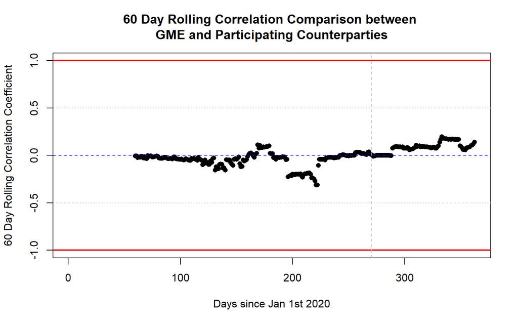

```r
# Calculate the 1-day Differences for each variable
xd = diff(joined_data$open, 1)
yd = diff(joined_data$Participating_Counterparties, 1)

# Calculate the 60-Day Rolling Correlation between the 2 variables' differences
x_y_roll_cor <- roll_cor(xd, yd, width = 60)

# Create a plot showing what the 60-Day Rolling Correlation looks like over time
plot(x_y_roll_cor,
     ylim = c(-1,1),
     pch = 16,
     xlab = 'Days since Jan 1st 2020',
     ylab = '60 Day Rolling Correlation Coefficient',
     main = '60 Day Rolling Correlation Comparison between \nGME and Participating Counterparties'
     )
abline(h=0, col = "blue", lty = 2)
abline(h=1, col = "red", lwd = 2)
abline(h=-1, col = "red", lwd = 2)
abline(h=0.5, col = "grey", lty = 3)
abline(h=-0.5, col = "grey", lty = 3)
abline(v=270, col = "grey", lty = 2)
```

## Using Differenced variables, calculate the 60-day Rolling Correlation between GME Open and Amount per Counterparty

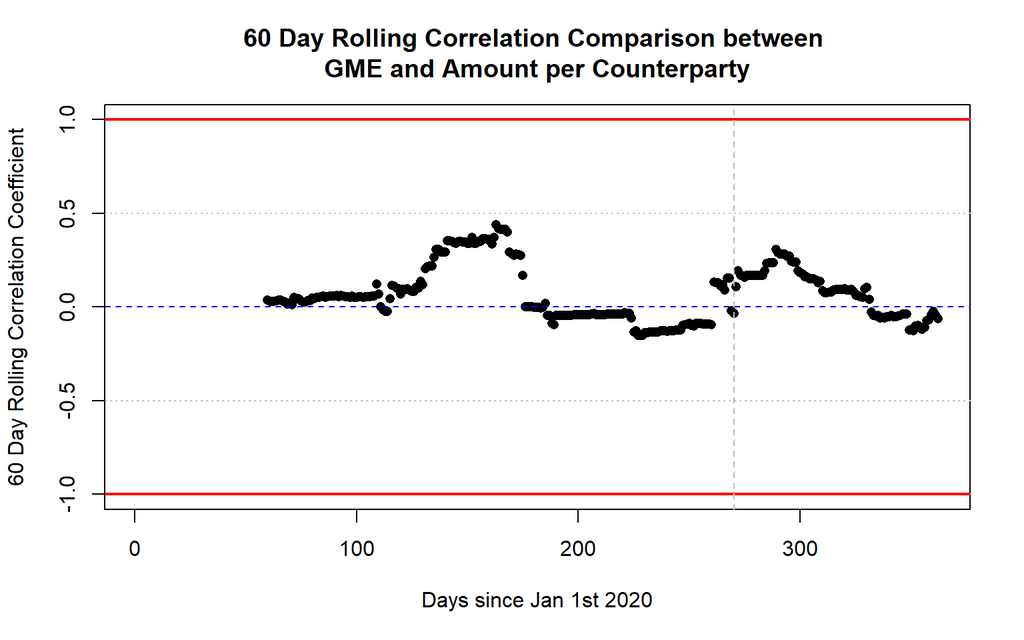

```r
# Add a feature for RRP Amount per Participating Counterparty
joined_data2 <- joined_data %>%
    mutate(amount_per_party = (Total_Accept/Participating_Counterparties)) %>%
    mutate(amount_per_party = replace(amount_per_party, is.na(amount_per_party), 0))

# Calculate the 1-day Differences for each variable
xd = diff(joined_data2$open, 1)
yd = diff(joined_data2$amount_per_party, 1)

# Calculate the 60-Day Rolling Correlation between the 2 variables' differences
x_y_roll_cor <- roll_cor(xd, yd, width = 60)

# Create a plot showing what the 60-Day Rolling Correlation looks like over time
plot(x_y_roll_cor,
     ylim = c(-1,1),
     pch = 16,
     xlab = 'Days since Jan 1st 2020',
     ylab = '60 Day Rolling Correlation Coefficient',
     main = '60 Day Rolling Correlation Comparison between \nGME and Amount per Counterparty'
     )
abline(h=0, col = "blue", lty = 2)
abline(h=1, col = "red", lwd = 2)
abline(h=-1, col = "red", lwd = 2)
abline(h=0.5, col = "grey", lty = 3)
abline(h=-0.5, col = "grey", lty = 3)
abline(v=270, col = "grey", lty = 2)
```